# Income Prediction with ‘mlr’ pacakge

Kyu Cho

September 29, 2016

# Introduction

The United States government periodically collects demographic information by conducting a census.

In this problem, we are going to use census information about an individual to predict how much a person earns – in particular, whether the person earns more than $50,000 per year. This data comes from the UCI Machine Learning Repository.

# Variables

- age = the age of the individual in years
- workclass = the classification of the individual’s working status (does the person work for the federal government, work for the local government, work without pay, and so on)
- education = the level of education of the individual (e.g., 5th-6th grade, high school graduate, PhD, so on)
- maritalstatus = the marital status of the individual
- occupation = the type of work the individual does (e.g., administrative/clerical work, farming/fishing, sales and so on)
- relationship = relationship of individual to his/her household
- race = the individual’s race
- sex = the individual’s sex
- capitalgain = the capital gains of the individual in 1994 (from selling an asset such as a stock or bond for more than the original purchase price)
- capitalloss = the capital losses of the individual in 1994 (from selling an asset such as a stock or bond for less than the original purchase price)
- hoursperweek = the number of hours the individual works per week
- nativecountry = the native country of the individual
- over50k = whether or not the individual earned more than $50,000 in 1994

# Table of Contents

1. Problem Statement & Hypothesis Generation (skiped)
2. Data Exploration
3. Data Cleaning
   - Missing Value Imputation
4. Data Manipulation a.k.a Feature Engineering
5. Machine Learning
   - Imbalanced Techniques
     - Oversampling
     - Undersampling
     - SMOTE
   - naive Bayes
   - XgBoost
     - Top 20 Features
     - AUC Threshold
   - SVM
     - Class weights

# Data Exploration

```r
# Set working directory
# path <- "F:/Google Drive/new_proj/project 101"
path <- "C:/Users/Kyu/Google Drive/Portfolio/project 101"
setwd(path)

# Load Data and clean the missing data label
library(data.table)
train <- fread("train.csv", na.strings = c("", " ", "?", "NA", NA))
test <- fread("test.csv", na.strings = c("", " ", "?", "NA", NA))
```

```r
# Look at data
dim(train)
```

```
## [1] 199523     41
```

```r
str (train)
```

```
## Classes 'data.table' and 'data.frame':   199523 obs. of  41 variables:
##  $ age                             : int  73 58 18 9 10 48 42 28 47 34 ...
##  $ class_of_worker                 : chr  "Not in universe" "Self-employed-not incorporated" "Not in universe" "Not in universe" ...
##  $ industry_code                   : int  0 4 0 0 0 40 34 4 43 4 ...
##  $ occupation_code                 : int  0 34 0 0 0 10 3 40 26 37 ...
##  $ education                       : chr  "High school graduate" "Some college but no degree" "10th grade" "Children" ...
##  $ wage_per_hour                   : int  0 0 0 0 0 1200 0 0 876 0 ...
##  $ enrolled_in_edu_inst_lastwk     : chr  "Not in universe" "Not in universe" "High school" "Not in universe" ...
##  $ marital_status                  : chr  "Widowed" "Divorced" "Never married" "Never married" ...
##  $ major_industry_code             : chr  "Not in universe or children" "Construction" "Not in universe or children" "Not in universe or children" ...
##  $ major_occupation_code           : chr  "Not in universe" "Precision production craft & repair" "Not in universe" "Not in universe" ...
##  $ race                            : chr  "White" "White" "Asian or Pacific Islander" "White" ...
##  $ hispanic_origin                 : chr  "All other" "All other" "All other" "All other" ...
##  $ sex                             : chr  "Female" "Male" "Female" "Female" ...
##  $ member_of_labor_union           : chr  "Not in universe" "Not in universe" "Not in universe" "Not in universe" ...
```

[output cut: 28 more lines]

```r
# Check first few rows of train & test
head(train)
```

```
##    age                class_of_worker industry_code occupation_code
## 1:  73                Not in universe             0               0
## 2:  58 Self-employed-not incorporated             4              34
## 3:  18                Not in universe             0               0
## 4:   9                Not in universe             0               0
## 5:  10                Not in universe             0               0
## 6:  48                        Private            40              10
##                     education wage_per_hour enrolled_in_edu_inst_lastwk
## 1:       High school graduate             0             Not in universe
## 2: Some college but no degree             0             Not in universe
## 3:                 10th grade             0                 High school
## 4:                   Children             0             Not in universe
## 5:                   Children             0             Not in universe
## 6: Some college but no degree          1200             Not in universe
##                     marital_status         major_industry_code
```

[output cut: 83 more lines]

```r
# Check target variables
unique(train$income_level)
```

```
## [1] "-50000" "+50000"
```

```r
unique(test$income_level)
```

```
## [1] "-50000"  "50000+."
```

Outputs are not the same, need to encode them correctly.

```r
train[ ,income_level := ifelse(income_level == "-50000", 0, 1)]
test[ ,income_level := ifelse(income_level == "-50000", 0, 1)]

# checking the severity of imbalanced classes
round(prop.table(table(train$income_level))*100)
```

```
##
##  0  1
## 94  6
```

The majority class has a proportion of 94%. In other words, with a decent ML algorithm, our model would get 94% model accuracy. In absolute figures, it looks incredible. But, our performance would depend on, how good can we predict the minority classes.

## Changing Variable Types

```r
# Converting variables into categorical and numerical
cat_cols <- c(2:5, 7, 8:16, 20:29, 31:38, 40,41)
num_cols <- setdiff(1:40, cat_cols) # Numeric columns are everything else

train[ ,(cat_cols) := lapply(.SD, factor), .SDcols=cat_cols]
train[ ,(num_cols) := lapply(.SD, as.numeric), .SDcols=num_cols]
test[ ,(cat_cols) := lapply(.SD, factor), .SDcols=cat_cols]
test[ ,(num_cols) := lapply(.SD, as.numeric), .SDcols=num_cols]

# Seperate Categorical and Numrical Values
cat_train <- train[ ,cat_cols, with=FALSE]
cat_test <- test[,cat_cols, with=FALSE]

num_train <- train[,num_cols, with=FALSE]
num_test <- test[,num_cols, with=FALSE]
rm(train, test) # remove original files to save the memory
```

## Visualization

### Numberical and Density

```r
library(ggplot2)
library(plotly)
# plot function
tr <- function(a){
     ggplot(data = num_train, aes(x= a, y=..density..)) +
          geom_histogram(fill="blue",color="red",alpha = 0.5,bins =100) +
          geom_density()
     ggplotly()}

# variable age
tr(num_train$age)
```

[interactive chart not shown]

1. The data set consists of people aged from 0 to 90 with frequency of people declining with age.
2. Population below age 20 couldn’t earn > 50K under normal circumstances.
   - bin this variable into age groups.

```r
# variable capital_losses
tr(num_train$capital_losses)
```

[interactive chart not shown]

1. In skewed distribution, normalizing is always an option.
2. But, we need to look into this variable deeper as this insight isn’t significant enough for decision making.
   - One option could be, to check for unique values. If they are less, we can tabulate the distribution.
3. More todo
   - Plot all other numerical variables as well

### Numerical vs Categorical

Since, it’s classification problem, plot numerical variables with dependent variable to find some cluster

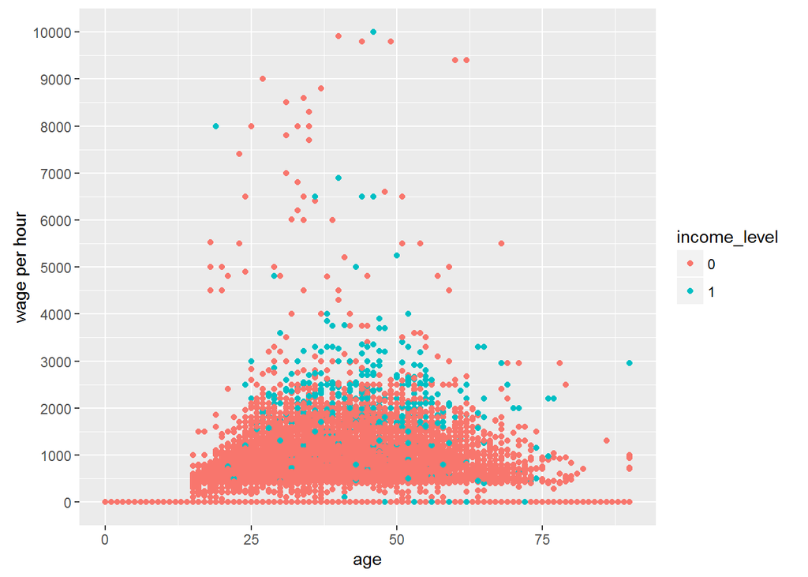

```r
# add target value
num_train[ ,income_level := cat_train$income_level]

# create a scatter plot
ggplot(data=num_train, aes(x=age, y=wage_per_hour)) +
     geom_point(aes(colour=income_level)) +
     scale_y_continuous("wage per hour", breaks = seq(0, 10000, 1000))
```

### Categorical vs Categorical

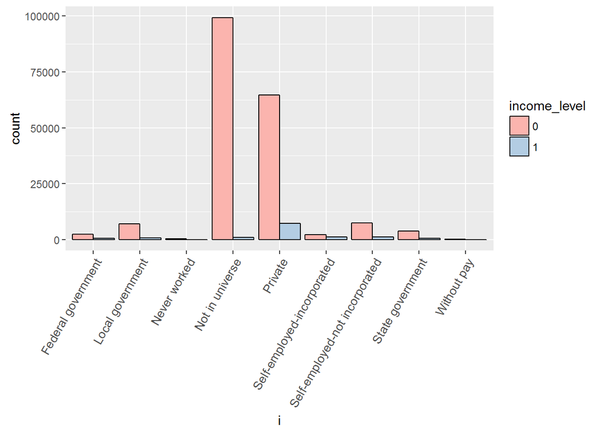

```r
library(ggplot2)
# plot function
all_bar <- function(i) {
     ggplot(cat_train, aes(x=i, fill=income_level)) +
          geom_bar(position = "dodge",  color="black") +
          scale_fill_brewer(palette = "Pastel1") +
          theme(axis.text.x=element_text(angle=60, hjust=1, size=10))
}
# variable class_of_worker
all_bar(cat_train$class_of_worker)
```

1. For ‘Not in universe’ category. Let’s assume that people got frustrated while filling their census data.
2. This variable looks imbalanced because only two category levels seem to dominate.
   - combine levels having less than 5% frequency of the total category frequency.

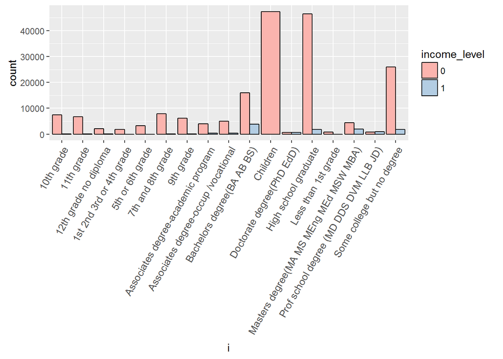

```r
# variable education
all_bar(cat_train$education)
```

Alternate ways is without the barchart is using the table.

```r
# Check the effect of dependent variable per categories
round(prop.table(table(cat_train$marital_status, cat_train$income_level), 1)*100)
```

```
##
##                                    0  1
##   Divorced                        92  8
##   Married-A F spouse present      98  2
##   Married-civilian spouse present 89 11
##   Married-spouse absent           94  6
##   Never married                   99  1
##   Separated                       95  5
##   Widowed                         97  3
```

```r
round(prop.table(table(cat_train$class_of_worker, cat_train$income_level), 1)*100)
```

```
##
##                                    0   1
##   Federal government              80  20
##   Local government                89  11
##   Never worked                   100   0
##   Not in universe                 99   1
##   Private                         90  10
##   Self-employed-incorporated      65  35
##   Self-employed-not incorporated  87  13
##   State government                89  11
##   Without pay                     99   1
```

# Data Cleaning

```r
# check missing values
table(is.na(num_train))
```

```
##
##   FALSE
## 1596184
```

```r
table(is.na(num_test))
```

```
##
##  FALSE
## 698334
```

```r
# remove highly corr. vars
library(caret)
num_train$income_level <- NULL
ax <- findCorrelation(x = cor(num_train), cutoff = 0.7)
num_train <- num_train[, -ax, with=FALSE]
num_test[, weeks_worked_in_year := NULL]

# check missing values per columns
mvtr <- sapply(cat_train, function(x){sum(is.na(x))/length(x)})*100
mvte <- sapply(cat_test, function(x){sum(is.na(x)/length(x))}*100)
mvtr
```

```
##                  class_of_worker                    industry_code
##                        0.0000000                        0.0000000
##                  occupation_code                        education
##                        0.0000000                        0.0000000
##      enrolled_in_edu_inst_lastwk                   marital_status
##                        0.0000000                        0.0000000
##              major_industry_code            major_occupation_code
##                        0.0000000                        0.0000000
##                             race                  hispanic_origin
##                        0.0000000                        0.4380447
##                              sex            member_of_labor_union
##                        0.0000000                        0.0000000
##          reason_for_unemployment    full_parttime_employment_stat
##                        0.0000000                        0.0000000
##                 tax_filer_status     region_of_previous_residence
##                        0.0000000                        0.0000000
##      state_of_previous_residence          d_household_family_stat
##                        0.3548463                        0.0000000
##              d_household_summary                    migration_msa
##                        0.0000000                       49.9671717
##                    migration_reg             migration_within_reg
##                       49.9671717                       49.9671717
##                  live_1_year_ago                migration_sunbelt
##                        0.0000000                       49.9671717
##          family_members_under_18                   country_father
##                        0.0000000                        3.3645244
##                   country_mother                     country_self
##                        3.0668144                        1.7005558
##                      citizenship        business_or_self_employed
##                        0.0000000                        0.0000000
## fill_questionnaire_veteran_admin                veterans_benefits
##                        0.0000000                        0.0000000
##                             year                     income_level
##                        0.0000000                        0.0000000
```

```r
mvte
```

```
##                  class_of_worker                    industry_code
##                        0.0000000                        0.0000000
##                  occupation_code                        education
##                        0.0000000                        0.0000000
##      enrolled_in_edu_inst_lastwk                   marital_status
##                        0.0000000                        0.0000000
##              major_industry_code            major_occupation_code
##                        0.0000000                        0.0000000
##                             race                  hispanic_origin
##                        0.0000000                        0.4059662
##                              sex            member_of_labor_union
##                        0.0000000                        0.0000000
##          reason_for_unemployment    full_parttime_employment_stat
##                        0.0000000                        0.0000000
##                 tax_filer_status     region_of_previous_residence
##                        0.0000000                        0.0000000
##      state_of_previous_residence          d_household_family_stat
##                        0.3307873                        0.0000000
##              d_household_summary                    migration_msa
##                        0.0000000                       50.0651551
##                    migration_reg             migration_within_reg
##                       50.0651551                       50.0651551
##                  live_1_year_ago                migration_sunbelt
##                        0.0000000                       50.0651551
##          family_members_under_18                   country_father
##                        0.0000000                        3.4371805
##                   country_mother                     country_self
##                        3.0793288                        1.7682083
##                      citizenship        business_or_self_employed
##                        0.0000000                        0.0000000
## fill_questionnaire_veteran_admin                veterans_benefits
##                        0.0000000                        0.0000000
##                             year                     income_level
##                        0.0000000                        0.0000000
```

```r
# remove ~50% missing values.
cat_train <- subset(cat_train, select = mvtr < 5 )
cat_test <- subset(cat_test, select = mvte < 5)


# set NA as 'Unavailable' - train data
# 1. convert to characters
cat_train <- cat_train[ ,names(cat_train) := lapply(.SD, as.character), .SDcols = names(cat_train)]
for (i in seq_along(cat_train)) set(cat_train, i=which(is.na(cat_train[[i]])), j=i, value="Unavailable")
# 2. convert back to factors
cat_train <- cat_train[, names(cat_train) := lapply(.SD,factor), .SDcols = names(cat_train)]

# set NA as 'Unavailable' - test data
# 1. convert to characters
cat_test <- cat_test[, (names(cat_test)) := lapply(.SD, as.character), .SDcols = names(cat_test)]
for (i in seq_along(cat_test)) set(cat_test, i=which(is.na(cat_test[[i]])), j=i, value="Unavailable")
# 2. convert back to factors
cat_test <- cat_test[, (names(cat_test)) := lapply(.SD, factor), .SDcols = names(cat_test)]
```

# Data Manipulation & Feature Engineering

1. Fix low frequencies by combining levels
2. Fix imbalanced classification
3. Remove zero variant variables

## Categorical Variables

```r
# combine factor levels with less than 5% values
# train set
for(i in names(cat_train)) {
     p <- 5/100
     ld <- names(which(prop.table(table(cat_train[[i]])) < p))
     levels(cat_train[[i]])[levels(cat_train[[i]]) %in% ld] <- "Other"
}

# test set
for(i in names(cat_test)){
                  p <- 5/100
                  ld <- names(which(prop.table(table(cat_test[[i]])) < p))
                  levels(cat_test[[i]])[levels(cat_test[[i]]) %in% ld] <- "Other"
}

# check the mismatch between categorical levels in train and test data.
# "nlevs" returns the unique number of level.
library(mlr)
summarizeColumns(cat_train)[, "nlevs"] == summarizeColumns(cat_test)[, "nlevs"]
```

```
##  [1] TRUE TRUE TRUE TRUE TRUE TRUE TRUE TRUE TRUE TRUE TRUE TRUE TRUE TRUE
## [15] TRUE TRUE TRUE TRUE TRUE TRUE TRUE TRUE TRUE TRUE TRUE TRUE TRUE TRUE
## [29] TRUE TRUE
```

## Numerical Variables

1. Look at numeric variables and reflect on possible ways for binning.
   - create simple tables representing counts of unique values in these variables.

```r
# counts of unique values and reorder them
num_train[, .N, age][order(age)]
num_train[, .N, wage_per_hour][order(-N)]
```

1. Todo
   - check other variables also.
2. It’s clear that more than 70-80% of the observations are 0 in these variables.
3. Bin these variables accordingly.
   - Use decision tree to determine the range of resultant bins.
     - It will be interested to see how 0-25, 26-65, 66-90 works (discerned from plots above).

```r
# bin age variable 0-30 31-60 61-90
# 'cut' function divides the range of x into intervals
num_train[, age:= cut(x=age, breaks=c(0,30,60,90), include.lowest=TRUE, labels=c("young","adult","old"))]
num_train[, age := factor(age)]

num_test[, age := cut(x=age, breaks=c(0,30,60,90), include.lowest=TRUE, labels=c("young","adult","old"))]
num_test[, age := factor(age)]

# Bin numeric variables with Zero and MoreThanZero
num_train[, wage_per_hour := ifelse(wage_per_hour == 0, "Zero", "MoreThanZero")][, wage_per_hour := as.factor(wage_per_hour)]
num_train[, capital_gains := ifelse(capital_gains == 0,"Zero", "MoreThanZero")][, capital_gains := as.factor(capital_gains)]
num_train[, capital_losses := ifelse(capital_losses == 0,"Zero", "MoreThanZero")][, capital_losses := as.factor(capital_losses)]
num_train[, dividend_from_Stocks := ifelse(dividend_from_Stocks == 0,"Zero","MoreThanZero")][,dividend_from_Stocks := as.factor(dividend_from_Stocks)]

num_test[, wage_per_hour := ifelse(wage_per_hour == 0, "Zero", "MoreThanZero")][, wage_per_hour := as.factor(wage_per_hour)]
num_test[, capital_gains := ifelse(capital_gains == 0, "Zero", "MoreThanZero")][, capital_gains := as.factor(capital_gains)]
num_test[, capital_losses := ifelse(capital_losses == 0, "Zero", "MoreThanZero")][, capital_losses := as.factor(capital_losses)]
num_test[, dividend_from_Stocks := ifelse(dividend_from_Stocks == 0, "Zero", "MoreThanZero")][, dividend_from_Stocks := as.factor(dividend_from_Stocks)]

# Now, we can remove the dependent variable from num_train.
num_train[, income_level := NULL]
```

# Machine Learning

Making predictions on this data should atleast give us ~94% accuracy. However, we need to know if we are predicting minority class correctly.

1. Sensitivity = True Positive Rate (TP/TP+FN)
   - ‘out of all the positive (majority class) values, how many have been predicted correctly’.
2. Specificity = True Negative Rate (FP/FP +FN)
   - ‘out of all the negative (minority class) values, how many have been predicted correctly’.
3. Precision = (TP/TP+FP)
4. Recall = Sensitivity
5. F score = 2 * (Precision * Recall)/ (Precision + Recall)
   - The harmonic mean of precision and recall, used to compare several models side-by-side. Higher the better.

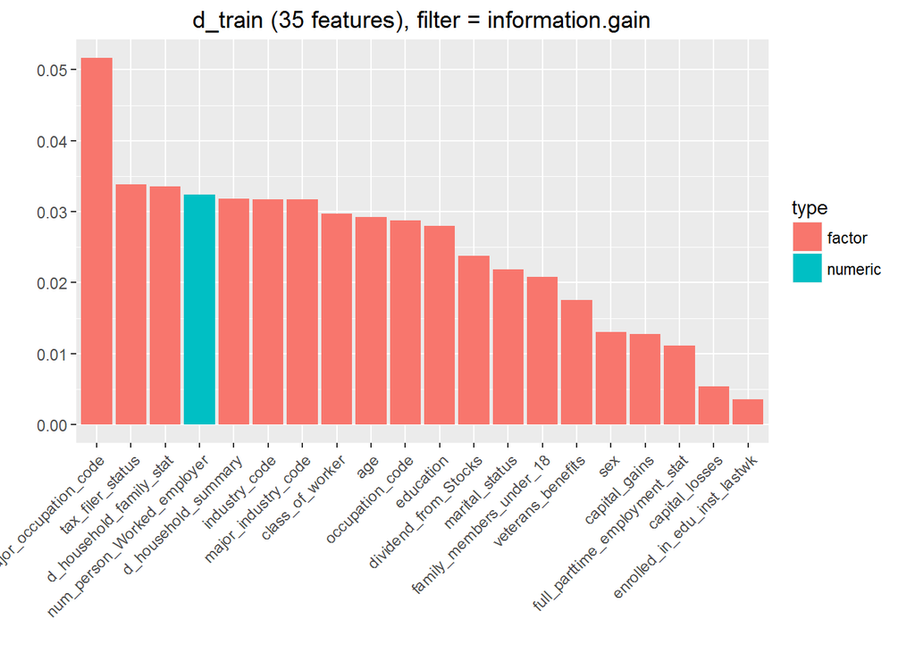

```r
# combine data and make test & train files
d_train <- cbind(num_train, cat_train)
d_test <- cbind(num_test, cat_test)
# remove unwanted files
rm(num_train, num_test, cat_train, cat_test) # save memory

# load library for machine learning
library(mlr)
library(FSelector)
# create task
train.task <- makeClassifTask(data=d_train,target="income_level")
test.task <- makeClassifTask(data=d_test,target="income_level")

# remove zero variance features
train.task <- removeConstantFeatures(train.task)
test.task <- removeConstantFeatures(test.task)

# get variable importance chart
var_imp <- generateFilterValuesData(train.task, method=c("information.gain"))
plotFilterValues(var_imp, feat.type.cols=TRUE)
```

1. ‘major_occupation_code’ provides highest information.
2. Balanced data using over sampling, undersampling and SMOTE.
   - In SMOTE, the algorithm looks at N-Nearest neighbors, measures the distance between them and introduces a new observation at the center of n observations.
     - These techniques have their own drawbacks such as:
       - undersampling leads to loss of information
       - oversampling leads to overestimation of minority class
3. Try all techniques and experience how it affects.

```r
# undersampling
train.under <- undersample(train.task, rate=0.1) # keep only 10% of majority class
table(getTaskTargets(train.under))
```

```
##
##     0     1
## 18714 12382
```

```r
# oversampling
train.over <- oversample(train.task, rate=15) # make minority class 15 times
table(getTaskTargets(train.over))
```

```
##
##      0      1
## 187141 185730
```

```r
# SMOTE # only works in binary classification
system.time(
     train.smote <- smote(train.task, rate=10, nn=3)
)
```

```
##    user  system elapsed
##   81.25    9.84   91.72
```

```r
table(getTaskTargets(train.smote))
```

```
##
##      0      1
## 187141 123820
```

```r
# lets see which algorithms are available
listLearners("classif", "twoclass")[c("class", "package")]
```

```
##                         class         package
## 1              classif.avNNet            nnet
## 2            classif.binomial           stats
## 3             classif.gausspr         kernlab
## 4                 classif.gbm             gbm
## 5                 classif.IBk           RWeka
## 6                 classif.J48           RWeka
## 7                classif.JRip           RWeka
## 8                 classif.knn           class
## 9                classif.ksvm         kernlab
## 10                classif.lda            MASS
## 11             classif.logreg           stats
## 12              classif.lssvm         kernlab
## 13               classif.lvq1           class
## 14           classif.multinom            nnet
## 15         classif.naiveBayes           e1071
## 16               classif.nnet            nnet
## 17               classif.OneR           RWeka
## 18               classif.PART           RWeka
## 19         classif.plsdaCaret           caret
## 20             classif.probit           stats
## 21                classif.qda            MASS
## 22       classif.randomForest    randomForest
## 23    classif.randomForestSRC randomForestSRC
## 24 classif.randomForestSRCSyn randomForestSRC
## 25              classif.rpart           rpart
## 26                classif.svm           e1071
## 27            classif.xgboost         xgboost
```

## Naive ayes

1. In case of high dimensional data like text-mining, naive Bayes tends to do wonders in accuracy, it works on categorical data.
2. In case of numeric variables, a normal distribution is considered for these variables and a mean and standard deviation is calculated. Then, using some standard z-table calculations probabilities can be estimated for each of your continuous variables to make the naive Bayes classifier.
3. Will use Naive Bayes on all 4 data sets (imbalanced, oversample, undersample and SMOTE) and compare the prediction accuracy using cross validation.

### Cross Validation

```r
# listLearners("classif","twoclass")[c("class","package")]
# create learner
naive_learner <- makeLearner("classif.naiveBayes", predict.type="response")
naive_learner$par.vals <- list(laplace=1)

# 10fold CV - stratified
folds <- makeResampleDesc("CV", iters=10, stratify=TRUE)

# cross validation function
fun_cv <- function(a){
     crv_val <- resample(naive_learner, a,folds, measures=list(acc,tpr,tnr,fpr,fp,fn))
     crv_val$aggr
}

fun_cv(train.task)
```

```
## acc.test.mean tpr.test.mean tnr.test.mean fpr.test.mean  fp.test.mean
##     0.7321963     0.7213919     0.8954938     0.1045062   129.4000000
##  fn.test.mean
##  5213.9000000
```

```r
# acc.test.mean tpr.test.mean tnr.test.mean fpr.test.mean  fp.test.mean  fn.test.mean
#     0.7170000     0.7052330     0.8948472     0.1051528   130.2000000  5516.3000000

fun_cv(train.under)
```

```
## acc.test.mean tpr.test.mean tnr.test.mean fpr.test.mean  fp.test.mean
##    0.76099889    0.66036259    0.91309931    0.08690069  107.60000000
##  fn.test.mean
##  635.60000000
```

```r
# acc.test.mean tpr.test.mean tnr.test.mean fpr.test.mean  fp.test.mean  fn.test.mean
#    0.75710670    0.65373426    0.91334197    0.08665803  107.30000000  648.00000000

fun_cv(train.over)
```

```
## acc.test.mean tpr.test.mean tnr.test.mean fpr.test.mean  fp.test.mean
##  7.849578e-01  6.554737e-01  9.154256e-01  8.457438e-02  1.570800e+03
##  fn.test.mean
##  6.447500e+03
```

```r
# acc.test.mean tpr.test.mean tnr.test.mean fpr.test.mean  fp.test.mean  fn.test.mean
#     0.7799668     0.6454545     0.9155010     0.0844990  1569.4000000  6635.0000000

fun_cv(train.smote)
```

```
## acc.test.mean tpr.test.mean tnr.test.mean fpr.test.mean  fp.test.mean
##  8.722702e-01  8.255540e-01  9.428768e-01  5.712324e-02  7.073000e+02
##  fn.test.mean
##  3.264600e+03
```

```r
# acc.test.mean tpr.test.mean tnr.test.mean fpr.test.mean  fp.test.mean  fn.test.mean
#     0.8595226     0.8096355     0.9349217     0.06507834   805.8000     3562.500
```

1. train.smote gives the highest true positive rate and true negative rate.
   - Hence, we learn that SMOTE technique outperforms the other two sampling methods.

### Build Model

```r
# create learner
naive_learner <- makeLearner("classif.naiveBayes", predict.type="response")
naive_learner$par.vals <- list(laplace=1)

# train and predict
nB_model <- train(naive_learner, train.smote)
nB_predict <- predict(nB_model, test.task)

# evaluate
nB_prediction <- nB_predict$data$response
dCM <- confusionMatrix(d_test$income_level, nB_prediction)
# Accuracy : 0.8105
# Sensitivity : 0.9855 -> majority class prediction
# Specificity : 0.2218 -> minority class prediction

# calculate F measure
precision <- dCM$byClass['Pos Pred Value']
recall <- dCM$byClass['Sensitivity']
f_measure_nB <- 2*((precision*recall)/(precision+recall))
print(f_measure_nB)
```

```
## Pos Pred Value
##       0.899187
```

## xgboost

Let’s use xgboost algorithm and try to improve our model. We’ll do 5 fold cross validation and 5 round random search for parameter tuning. Finally, we’ll build the model using the best tuned parameters.

### Cross Validation

```r
set.seed(2002)
# create learner
xgb_learner <- makeLearner("classif.xgboost", predict.type="response")
xgb_learner$par.vals <- list(
     objective = "binary:logistic",
     eval_metric = "error",
     nrounds = 150,
     print.every.n = 50)

# set parameters
xg_ps <- makeParamSet(
     makeIntegerParam("max_depth",lower=3, upper=10),
     makeNumericParam("lambda",lower=0.05, upper=0.5),
     makeNumericParam("eta", lower = 0.01, upper = 0.5),
     makeNumericParam("subsample", lower = 0.50, upper=1),
     makeNumericParam("min_child_weight",lower=2,upper=10),
     makeNumericParam("colsample_bytree",lower = 0.50,upper=0.80))

# set search funtion
rancontrol <- makeTuneControlRandom(maxit=5L) # do 5 iterations

# set cross validation
set_cv <- makeResampleDesc("CV", iters=5L, stratify = TRUE)

# set tune parameters
xgb_tune <- tuneParams(learner=xgb_learner, task=train.task, resampling=set_cv,
                       measures=list(acc,tpr,tnr,fpr,fp,fn), par.set=xg_ps, control=rancontrol)
# Tune result:
# max_depth=3; lambda=0.243; eta=0.233; subsample=0.936; min_child_weight=2.92; colsample_bytree=0.793 :
# acc.test.mean=0.945,tpr.test.mean=0.989,tnr.test.mean=0.285,fpr.test.mean=0.715,fp.test.mean=1.77e+03,fn.test.mean= 403
```

### Build Model

```r
# set hyperparameters
xgb_new <- setHyperPars(learner=xgb_learner, par.vals=xgb_tune$x)

# train model
xgmodel <- train(xgb_new, train.task)
# test model
predict.xg <- predict(xgmodel, test.task)

# make prediction
xg_prediction <- predict.xg$data$response

# make confusion matrix
xg_confused <- confusionMatrix(d_test$income_level,xg_prediction)
# Accuracy : 0.948
# Sensitivity : 0.9574
# Specificity : 0.6585

# calculate f-measure
precision <- xg_confused$byClass['Pos Pred Value']
recall <- xg_confused$byClass['Sensitivity']
f_measure_xg <- 2*((precision*recall)/(precision+recall))
print(f_measure_xg)
```

```
## Pos Pred Value
##      0.9726492
```

1. xgboost has outperformed naive Bayes model’s accuracy
2. Todo
   - Try using the important variables only.

### Cross Validation

```r
filtered.data <- filterFeatures(train.task, method = "information.gain", abs = 20)

# set tune parameters
xgb_tune2 <- tuneParams(learner=xgb_learner, task=filtered.data, resampling=set_cv,
                       measures=list(acc,tpr,tnr,fpr,fp,fn), par.set=xg_ps, control=rancontrol)
# Op. pars: max_depth=6; lambda=0.244; eta=0.181; subsample=0.697; min_child_weight=2.15; colsample_bytree=0.742
# acc.test.mean=0.945,tpr.test.mean=0.988,tnr.test.mean=0.294,fpr.test.mean=0.706,fp.test.mean=1.75e+03,fn.test.mean= 434
```

### Build Model

```r
# set hyperparameters
xgb_new2 <- setHyperPars(learner=xgb_learner, par.vals=xgb_tune2$x)

# train model
xgmodel2 <- train(xgb_new, filtered.data)
# test model
predict.xg <- predict(xgmodel2, test.task)

# make prediction
xg_prediction <- predict.xg$data$response

# make confusion matrix
xg_confused <- confusionMatrix(d_test$income_level,xg_prediction)
# Accuracy : 0.948
# Sensitivity : 0.9574
# Specificity : 0.6585

# calculate f-measure
precision <- xg_confused$byClass['Pos Pred Value']
recall <- xg_confused$byClass['Sensitivity']
f_measure_xg2 <- 2*((precision*recall)/(precision+recall))
print(f_measure_xg2)
```

```
## Pos Pred Value
##             NA
```

### AUC tunning

- Threshold of 0.5 favors the majority class
  - Adjust the threshold for better prediction using AUC Curve

```r
# xgboost chnage to probabiliy for AUC
xgb_new <- setHyperPars(learner=xgb_learner, par.vals=xgb_tune$x)
xgb_prob <- setPredictType(learner=xgb_new, predict.type="prob")

# train model
xgmodel_prob <- train(xgb_prob, train.task)
# predict
predict.xgprob <- predict(xgmodel_prob, test.task)

# predicted probabilities
predict.xgprob$data[1:10, ]
```

```
##    id truth    prob.0       prob.1 response
## 1   1     0 0.9967919 3.208110e-03        0
## 2   2     0 0.7980185 2.019815e-01        0
## 3   3     0 0.9999955 4.541979e-06        0
## 4   4     0 0.9583654 4.163465e-02        0
## 5   5     0 0.9688377 3.116228e-02        0
## 6   6     0 0.9999399 6.005286e-05        0
## 7   7     0 0.9999952 4.762664e-06        0
## 8   8     0 0.9978574 2.142623e-03        0
## 9   9     0 0.7905364 2.094636e-01        0
## 10 10     0 0.9999944 5.629365e-06        0
```

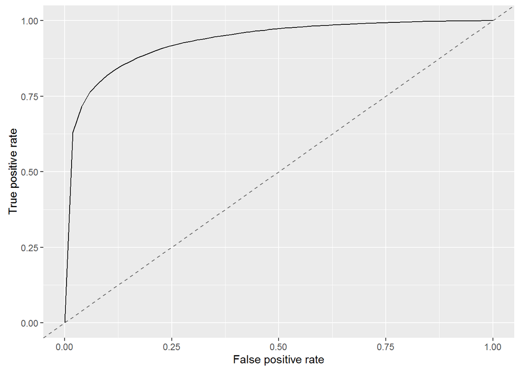

```r
df <- generateThreshVsPerfData(predict.xgprob, measures=list(fpr,tpr))
plotROCCurves(df)
```

```r
# set threshold as 0.4
pred2 <- setThreshold(predict.xgprob, 0.4)
xg_confused <- confusionMatrix(d_test$income_level, pred2$data$response)
# Accuracy : 0.9449
# Sensitivity : 0.9498
# Specificity : 0.6871

# calculate f-measure
precision <- xg_confused$byClass['Pos Pred Value']
recall <- xg_confused$byClass['Sensitivity']
f_measure_xg3 <- 2*((precision*recall)/(precision+recall))

# set threshold as 0.4
pred3 <- setThreshold(predict.xgprob, 0.3)
xg_confused <- confusionMatrix(d_test$income_level, pred3$data$response)
# Accuracy : 0.942
# Sensitivity :  0.9438
# Specificity : 0.7339

# calculate f-measure
precision <- xg_confused$byClass['Pos Pred Value']
recall <- xg_confused$byClass['Sensitivity']
f_measure_xg4 <- 2*((precision*recall)/(precision+recall))
print(f_measure_xg4)
```

```
## Pos Pred Value
##      0.9716973
```

1. This model has outperformed all our models because 73% of the minority classes have been predicted correctly.
2. Todo
   - Test other threshold values to check if your model improves.
   - Increase the number of rounds
   - Do 10 fold CV
   - Increase repetitions in random search
   - Build models on other 3 data sets and see which one is better
   - Assign class weights such that the algorithm pays more attention while classifying the class with higher weight.

## SVM

```r
# # create learner
# getParamSet("classif.svm")
# svm_learner <- makeLearner("classif.svm", predict.type="response")
# svm_learner$par.vals<- list(class.weights=c("0"=1, "1"=10), kernel="radial")
#
# # set parameters
# svm_param <- makeParamSet(
#      makeIntegerParam("cost", lower = 10^-1, upper=10^2),
#      makeIntegerParam("gamma", lower= 0.5, upper=2))
#
# # set search funtion
# set_search <- makeTuneControlRandom(maxit=5L) #5 times
#
# # set cross validation
# set_cv <- makeResampleDesc("CV", iters=5L, stratify=TRUE)
#
# # set tune parameters
# svm_tune <- tuneParams(learner=svm_learner, task=train.task, measures=list(acc,tpr,tnr,fpr,fp,fn),
#                        par.set=svm_param, control=set_search, resampling=set_cv)
#
# # set hyperparameters
# svm_new <- setHyperPars(learner=svm_learner, par.vals=svm_tune$x)
#
# # train model
# svm_model <- train(svm_new, train.task)
#
# # test model
# predict_svm <- predict(svm_model, test.task)
#
# # make confusion matrix
# svm_confused <- confusionMatrix(d_test$income_level, predict_svm$data$response)
# svm_confused
#
# # calculate f-measure
# precision <- svm_confused$byClass['Pos Pred Value']
# recall <- svm_confused$byClass['Sensitivity']
# f_measure_svm <- 2*((precision*recall)/(precision+recall))
```

## KNN

```r
# # create learner
# getParamSet("classif.knn")
# knn.learner <- makeLearner("classif.knn",predict.type = "response") #create task > iris.task
#
# # set parameters
# params <- makeParamSet(makeIntegerParam("k",lower=1, upper=25))
#
# # set search funtion
# grid_cv <- makeTuneControlGrid()
#
# # set cross validation
# set_cv <- makeResampleDesc("RepCV", reps=15, folds=10, stratify=TRUE)
#
# # set tune parameters
# tune.knn <- tuneParams(learner=knn.learner, task=train.task, resampling=set_cv,
#                        measures=acc, par.set=params, control = grid_cv)
#
# # set hyperparameters
# knn_new <- setHyperPars(learner=knn.learner, par.vals=tune.knn$x)
#
# # train model
# knn_model <- train(knn_new, train.task)
#
# # test model
# predict_knn <- predict(knn_model, test.task)
#
# # make confusion matrix
# knn_confused <- confusionMatrix(d_test$income_level, predict_knn$data$response)
# knn_confused
#
# # calculate f-measure
# precision <- knn_confused$byClass['Pos Pred Value']
# recall <- knn_confused$byClass['Sensitivity']
# f_measure_knn <- 2*((precision*recall)/(precision+recall))
```

```r
# model_name <- c("Naive", "xgb_normal_.5","xgb_imp.var", "xgb_normal_.3", "xgb_normal_.4", "knn")
# model_f_val <- c(f_measure_nB, f_measure_xg, f_measure_xg2, f_measure_xg3, f_measure_xg4, f_measure_knn)
#
# data.frame(model_name, model_f_val)
```